# Analytics Edge: Unit 1

Sulman Khan

October 23, 2018

## Introduction to Analytics Edge

### Prevalence of Data

- 2.7 Zettabytes of electronic data exist in the world today - 2,700,000,000,000,000,000,000 bytes
  - This is equal to the storage required for more than 200 billion HD movies
- New data is produced at an exponential rate
- Decoding the human genome originally took 10 years to process; now it can be achieved in one week

### Data and Analytics are Useful

- Estimated that there is a shortage of 140,000 - 190,000 people with deep analytical skills to fill the demand of  
  jobs in the U.S. by 2018
- IBM has invested over $20 billion since 2005 to grow its analytics business
- Companies will invest more than $120 billion by 2015 on analytics, hardware, software and services
- Critical in almost every industry
  - Healthcare, media, sports, finance, government, etc.

### Definition of Analytics

The science of using **data** to build **models** that lead to better **decisions** that add **value** to individuals, to companies, and to institutions.

### Examples of Data Anlytics Used

#### IBM Watson

- Watson is a supercomputer with 3,000 processors and a database of 200 million pages of information
- Watson combined many algorithms to increase accuracy and confidence
- Approached the problem in a different way than how a human does
- Deals with massive amounts of data, often in unstructured form
  - 90% of data in the world is unstructured

#### eHarmony

- Online dating site focused on long term relationships
- Relies much more on data than other dating sites
- Suggests a limited number of high quality matches
  - Users don’t have to search and dig through profiles
- eHarmony has successfully leveraged the power of  
  analytics to create a successful and thriving business
  - 14% of US online dating market

#### The Framingham Heart Study

- Much of the now-common knowledge regarding heart disease came from this study
- Provided necessary evidence for the development of drugs to lower blood pressure
- Paved the way for other clinical prediction rules
  - Predict clinical outcomes using patient data
- A model allows medical professionals to make predictions for patients worldwide

#### D2Hawkeye

- Combined data with analytics to improve quality and cost management in healthcare
- Substantial improvement in D2Hawkeye’s ability to identify patients who need more attention
- Use expert knowledge to identify new variables and refine existing variables
- Can make predictions for millions of patients without manually reading patient files

## An Introduction to R

### What is R?

- A software environment for data analysis, statistical computing, and graphics
- A programming language

In the next section, the basic operations and functions used in R for data analysis are explored.

### Basic Calculations

```r
8*6
```

```
## [1] 48
```

```r
2^16
```

```
## [1] 65536
```

```r
8*6
```

```
## [1] 48
```

```r
8*10
```

```
## [1] 80
```

### Functions

```r
sqrt(2)
```

```
## [1] 1.414214
```

```r
abs(-65)
```

```
## [1] 65
```

### Variables

```r
SquareRoot2 = sqrt(2)
SquareRoot2
```

```
## [1] 1.414214
```

```r
HoursYear <- 365*24
HoursYear
```

```
## [1] 8760
```

```r
ls()
```

```
## [1] "HoursYear"   "SquareRoot2"
```

### Vectors

Two vectors - **Country** and **LifeExpectancy** are created. Accordingly, both vectors are indexed to display specific elements inside the vectors. Finally, a third vector **Sequence** has a range from 0 to 100 in increments of 2.

```r
c(2,3,5,8,13)
```

```
## [1]  2  3  5  8 13
```

```r
Country = c("Brazil", "China", "India","Switzerland","USA")
LifeExpectancy = c(74,76,65,83,79)
Country
```

```
## [1] "Brazil"      "China"       "India"       "Switzerland" "USA"
```

```r
LifeExpectancy
```

```
## [1] 74 76 65 83 79
```

```r
Country[1]
```

```
## [1] "Brazil"
```

```r
LifeExpectancy[3]
```

```
## [1] 65
```

```r
Sequence = seq(0,100,2)
Sequence
```

```
##  [1]   0   2   4   6   8  10  12  14  16  18  20  22  24  26  28  30  32  34  36  38  40  42  44  46  48  50  52  54  56  58  60  62  64  66  68  70  72  74  76
## [40]  78  80  82  84  86  88  90  92  94  96  98 100
```

### Data Frames

The data.frame **CountryData** calls upon the two vectors **Country** and **LifeExpectancy**. Successivly, an additional vector **CountryData$Populations** is added to the data.frame. Finally, a data.frame **AllCountryData** utilizes the two previous data.frames **CountryData** and **NewCountryData**.

```r
CountryData = data.frame(Country, LifeExpectancy)
CountryData
```

```
##       Country LifeExpectancy
## 1      Brazil             74
## 2       China             76
## 3       India             65
## 4 Switzerland             83
## 5         USA             79
```

```r
CountryData$Population = c(199000,1390000,1240000,7997,318000)
CountryData
```

```
##       Country LifeExpectancy Population
## 1      Brazil             74     199000
## 2       China             76    1390000
## 3       India             65    1240000
## 4 Switzerland             83       7997
## 5         USA             79     318000
```

```r
Country = c("Australia","Greece")
LifeExpectancy = c(82,81)
Population = c(23050,11125)
NewCountryData = data.frame(Country, LifeExpectancy, Population)
NewCountryData
```

```
##     Country LifeExpectancy Population
## 1 Australia             82      23050
## 2    Greece             81      11125
```

```r
AllCountryData = rbind(CountryData, NewCountryData)
AllCountryData
```

```
##       Country LifeExpectancy Population
## 1      Brazil             74     199000
## 2       China             76    1390000
## 3       India             65    1240000
## 4 Switzerland             83       7997
## 5         USA             79     318000
## 6   Australia             82      23050
## 7      Greece             81      11125
```

### Loading csv files

The dataset **WHO.csv** is loaded into the variable **WHO**. The str and summary commands provide physical and statistical descriptions of the variable.

```r
WHO = read.csv("WHO.csv")
str(WHO)
```

```
## 'data.frame':    194 obs. of  13 variables:
##  $ Country                      : Factor w/ 194 levels "Afghanistan",..: 1 2 3 4 5 6 7 8 9 10 ...
##  $ Region                       : Factor w/ 6 levels "Africa","Americas",..: 3 4 1 4 1 2 2 4 6 4 ...
##  $ Population                   : int  29825 3162 38482 78 20821 89 41087 2969 23050 8464 ...
##  $ Under15                      : num  47.4 21.3 27.4 15.2 47.6 ...
##  $ Over60                       : num  3.82 14.93 7.17 22.86 3.84 ...
##  $ FertilityRate                : num  5.4 1.75 2.83 NA 6.1 2.12 2.2 1.74 1.89 1.44 ...
##  $ LifeExpectancy               : int  60 74 73 82 51 75 76 71 82 81 ...
##  $ ChildMortality               : num  98.5 16.7 20 3.2 163.5 ...
##  $ CellularSubscribers          : num  54.3 96.4 99 75.5 48.4 ...
##  $ LiteracyRate                 : num  NA NA NA NA 70.1 99 97.8 99.6 NA NA ...
##  $ GNI                          : num  1140 8820 8310 NA 5230 ...
##  $ PrimarySchoolEnrollmentMale  : num  NA NA 98.2 78.4 93.1 91.1 NA NA 96.9 NA ...
##  $ PrimarySchoolEnrollmentFemale: num  NA NA 96.4 79.4 78.2 84.5 NA NA 97.5 NA ...
```

```r
summary(WHO)
```

```
##                 Country                      Region     Population         Under15          Over60      FertilityRate   LifeExpectancy  ChildMortality
##  Afghanistan        :  1   Africa               :46   Min.   :      1   Min.   :13.12   Min.   : 0.81   Min.   :1.260   Min.   :47.00   Min.   :  2.200
##  Albania            :  1   Americas             :35   1st Qu.:   1696   1st Qu.:18.72   1st Qu.: 5.20   1st Qu.:1.835   1st Qu.:64.00   1st Qu.:  8.425
##  Algeria            :  1   Eastern Mediterranean:22   Median :   7790   Median :28.65   Median : 8.53   Median :2.400   Median :72.50   Median : 18.600
##  Andorra            :  1   Europe               :53   Mean   :  36360   Mean   :28.73   Mean   :11.16   Mean   :2.941   Mean   :70.01   Mean   : 36.149
##  Angola             :  1   South-East Asia      :11   3rd Qu.:  24535   3rd Qu.:37.75   3rd Qu.:16.69   3rd Qu.:3.905   3rd Qu.:76.00   3rd Qu.: 55.975
##  Antigua and Barbuda:  1   Western Pacific      :27   Max.   :1390000   Max.   :49.99   Max.   :31.92   Max.   :7.580   Max.   :83.00   Max.   :181.600
##  (Other)            :188                                                                                NA's   :11
##  CellularSubscribers  LiteracyRate        GNI        PrimarySchoolEnrollmentMale PrimarySchoolEnrollmentFemale
##  Min.   :  2.57      Min.   :31.10   Min.   :  340   Min.   : 37.20              Min.   : 32.50
##  1st Qu.: 63.57      1st Qu.:71.60   1st Qu.: 2335   1st Qu.: 87.70              1st Qu.: 87.30
##  Median : 97.75      Median :91.80   Median : 7870   Median : 94.70              Median : 95.10
##  Mean   : 93.64      Mean   :83.71   Mean   :13321   Mean   : 90.85              Mean   : 89.63
##  3rd Qu.:120.81      3rd Qu.:97.85   3rd Qu.:17558   3rd Qu.: 98.10              3rd Qu.: 97.90
##  Max.   :196.41      Max.   :99.80   Max.   :86440   Max.   :100.00              Max.   :100.00
##  NA's   :10          NA's   :91      NA's   :32      NA's   :93                  NA's   :93
```

### Subsetting

The dataset **WHO** is subsetted into **WHO_Europe** using the region as an argument to collect the data.

```r
WHO_Europe = subset(WHO, Region == "Europe")
str(WHO_Europe)
```

```
## 'data.frame':    53 obs. of  13 variables:
##  $ Country                      : Factor w/ 194 levels "Afghanistan",..: 2 4 8 10 11 16 17 22 26 42 ...
##  $ Region                       : Factor w/ 6 levels "Africa","Americas",..: 4 4 4 4 4 4 4 4 4 4 ...
##  $ Population                   : int  3162 78 2969 8464 9309 9405 11060 3834 7278 4307 ...
##  $ Under15                      : num  21.3 15.2 20.3 14.5 22.2 ...
##  $ Over60                       : num  14.93 22.86 14.06 23.52 8.24 ...
##  $ FertilityRate                : num  1.75 NA 1.74 1.44 1.96 1.47 1.85 1.26 1.51 1.48 ...
##  $ LifeExpectancy               : int  74 82 71 81 71 71 80 76 74 77 ...
##  $ ChildMortality               : num  16.7 3.2 16.4 4 35.2 5.2 4.2 6.7 12.1 4.7 ...
##  $ CellularSubscribers          : num  96.4 75.5 103.6 154.8 108.8 ...
##  $ LiteracyRate                 : num  NA NA 99.6 NA NA NA NA 97.9 NA 98.8 ...
##  $ GNI                          : num  8820 NA 6100 42050 8960 ...
##  $ PrimarySchoolEnrollmentMale  : num  NA 78.4 NA NA 85.3 NA 98.9 86.5 99.3 94.8 ...
##  $ PrimarySchoolEnrollmentFemale: num  NA 79.4 NA NA 84.1 NA 99.2 88.4 99.7 97 ...
```

### Writing csv files

```r
write.csv(WHO_Europe, "WHO_Europe.csv")
```

### Removing variables

```r
rm(WHO_Europe)
```

### Basic Data Analysis

Various basic data analysis commands are implemented to provide a statistical summary of the datasets and how to appropriately identify various elements of interest.

```r
mean(WHO$Under15)
```

```
## [1] 28.73242
```

```r
sd(WHO$Under15)
```

```
## [1] 10.53457
```

```r
summary(WHO$Under15)
```

```
##    Min. 1st Qu.  Median    Mean 3rd Qu.    Max.
##   13.12   18.72   28.65   28.73   37.75   49.99
```

```r
which.min(WHO$Under15)
```

```
## [1] 86
```

```r
WHO$Country[86]
```

```
## [1] Japan
## 194 Levels: Afghanistan Albania Algeria Andorra Angola Antigua and Barbuda Argentina Armenia Australia Austria Azerbaijan Bahamas Bahrain ... Zimbabwe
```

```r
which.max(WHO$Under15)
```

```
## [1] 124
```

```r
WHO$Country[124]
```

```
## [1] Niger
## 194 Levels: Afghanistan Albania Algeria Andorra Angola Antigua and Barbuda Argentina Armenia Australia Austria Azerbaijan Bahamas Bahrain ... Zimbabwe
```

### Scatterplot

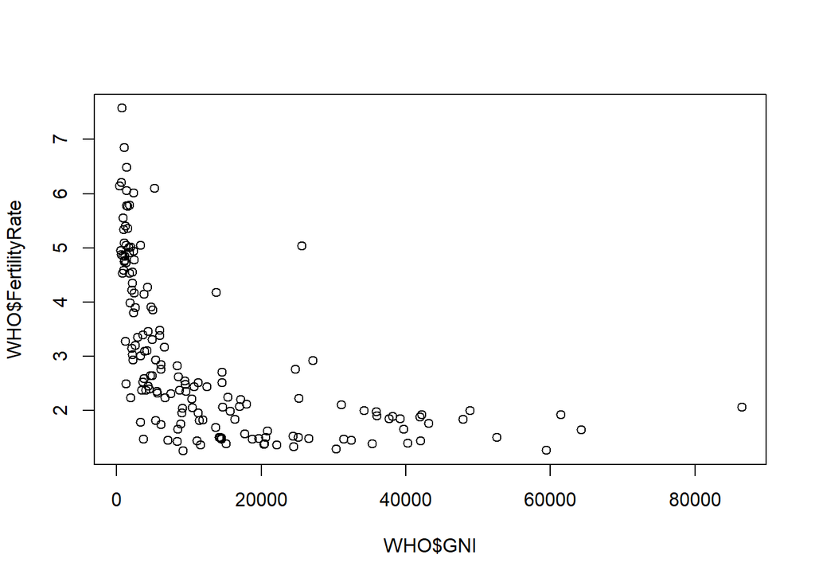

```r
plot(WHO$GNI, WHO$FertilityRate)
```

### Subsetting Outliers

```r
Outliers = subset(WHO, GNI > 10000 & FertilityRate > 2.5)
nrow(Outliers)
```

```
## [1] 7
```

```r
Outliers[c("Country","GNI","FertilityRate")]
```

```
##               Country   GNI FertilityRate
## 23           Botswana 14550          2.71
## 56  Equatorial Guinea 25620          5.04
## 63              Gabon 13740          4.18
## 83             Israel 27110          2.92
## 88         Kazakhstan 11250          2.52
## 131            Panama 14510          2.52
## 150      Saudi Arabia 24700          2.76
```

### Histograms

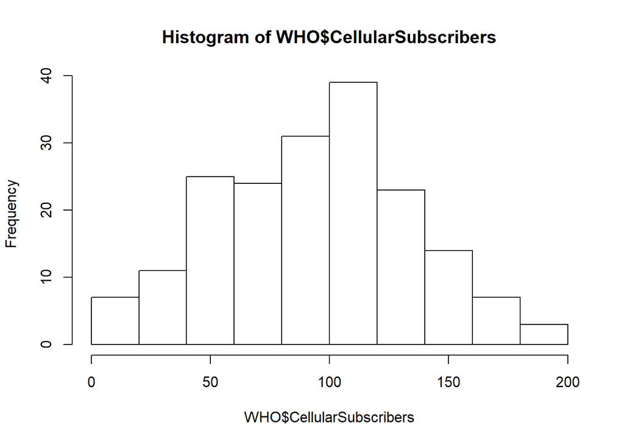

```r
hist(WHO$CellularSubscribers)
```

### Boxplot

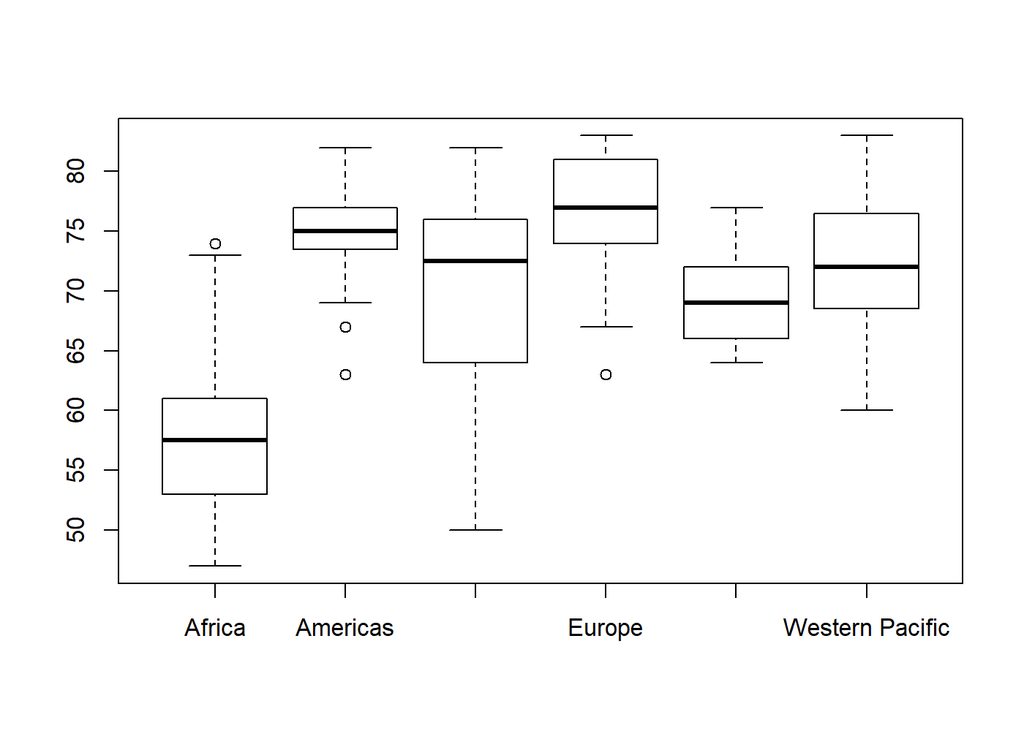

```r
boxplot(WHO$LifeExpectancy ~ WHO$Region)
```

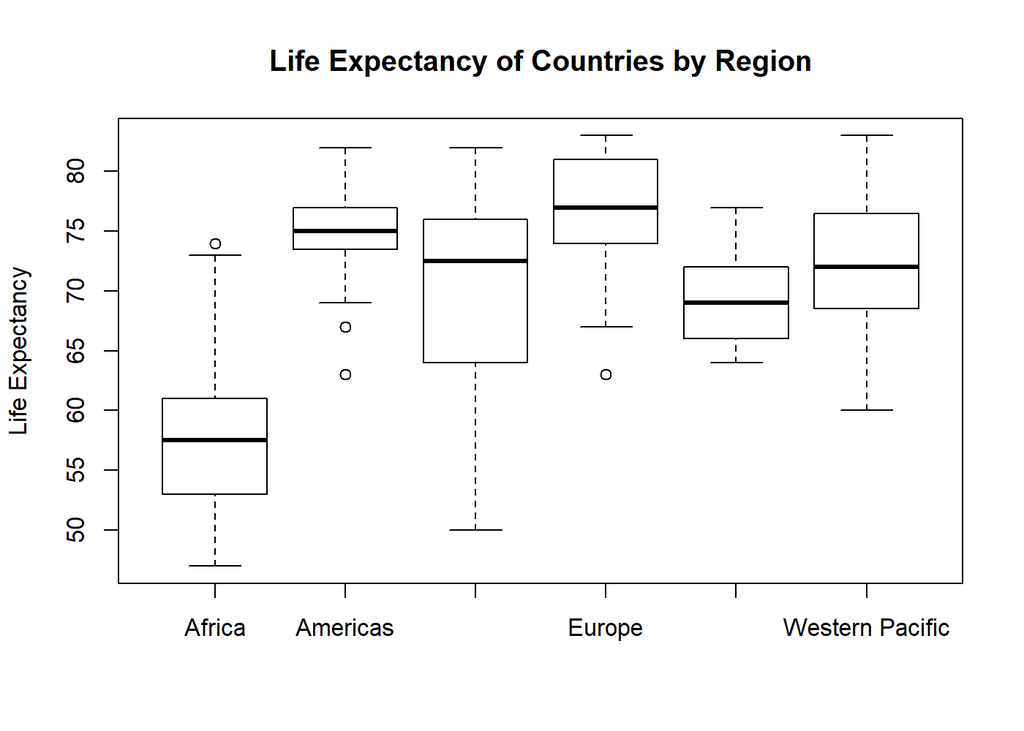

```r
boxplot(WHO$LifeExpectancy ~ WHO$Region, xlab = "", ylab = "Life Expectancy", main = "Life Expectancy of Countries by Region")
```

### Summary Tables

The **table** command creates a table for each region in the **WHO** data.frame. The **tapply** command demonstrates the relationship between two vectors in the data.frame using a statistical descriptor.

```r
table(WHO$Region)
```

```
##
##                Africa              Americas Eastern Mediterranean                Europe       South-East Asia       Western Pacific
##                    46                    35                    22                    53                    11                    27
```

```r
tapply(WHO$Over60, WHO$Region, mean)
```

```
##                Africa              Americas Eastern Mediterranean                Europe       South-East Asia       Western Pacific
##              5.220652             10.943714              5.620000             19.774906              8.769091             10.162963
```

```r
tapply(WHO$LiteracyRate, WHO$Region, min)
```

```
##                Africa              Americas Eastern Mediterranean                Europe       South-East Asia       Western Pacific
##                    NA                    NA                    NA                    NA                    NA                    NA
```

```r
tapply(WHO$LiteracyRate, WHO$Region, min, na.rm=TRUE)
```

```
##                Africa              Americas Eastern Mediterranean                Europe       South-East Asia       Western Pacific
##                  31.1                  75.2                  63.9                  95.2                  56.8                  60.6
```

## Understanding Food USDA Dataset

In the following section, the United States Department of Agriculture (USDA) dataset on the dietary contents of food is examined.

### Loading in the Dataset

#### Read the csv file

```r
  USDA = read.csv("USDA.csv")
```

#### Structure of the dataset

```r
  str(USDA)
```

```
## 'data.frame':    7058 obs. of  16 variables:
##  $ ID          : int  1001 1002 1003 1004 1005 1006 1007 1008 1009 1010 ...
##  $ Description : Factor w/ 7054 levels "ABALONE,MIXED SPECIES,RAW",..: 1303 1302 1298 2303 2304 2305 2306 2307 2308 2309 ...
##  $ Calories    : int  717 717 876 353 371 334 300 376 403 387 ...
##  $ Protein     : num  0.85 0.85 0.28 21.4 23.24 ...
##  $ TotalFat    : num  81.1 81.1 99.5 28.7 29.7 ...
##  $ Carbohydrate: num  0.06 0.06 0 2.34 2.79 0.45 0.46 3.06 1.28 4.78 ...
##  $ Sodium      : int  714 827 2 1395 560 629 842 690 621 700 ...
##  $ SaturatedFat: num  51.4 50.5 61.9 18.7 18.8 ...
##  $ Cholesterol : int  215 219 256 75 94 100 72 93 105 103 ...
##  $ Sugar       : num  0.06 0.06 0 0.5 0.51 0.45 0.46 NA 0.52 NA ...
##  $ Calcium     : int  24 24 4 528 674 184 388 673 721 643 ...
##  $ Iron        : num  0.02 0.16 0 0.31 0.43 0.5 0.33 0.64 0.68 0.21 ...
##  $ Potassium   : int  24 26 5 256 136 152 187 93 98 95 ...
##  $ VitaminC    : num  0 0 0 0 0 0 0 0 0 0 ...
##  $ VitaminE    : num  2.32 2.32 2.8 0.25 0.26 0.24 0.21 NA 0.29 NA ...
##  $ VitaminD    : num  1.5 1.5 1.8 0.5 0.5 0.5 0.4 NA 0.6 NA ...
```

#### Statistical summary

```r
  summary(USDA)
```

```
##        ID                                                              Description      Calories        Protein         TotalFat       Carbohydrate
##  Min.   : 1001   BEEF,CHUCK,UNDER BLADE CNTR STEAK,BNLESS,DENVER CUT,LN,0" FA:   2   Min.   :  0.0   Min.   : 0.00   Min.   :  0.00   Min.   :  0.00
##  1st Qu.: 8387   CAMPBELL,CAMPBELL'S SEL MICROWAVEABLE BOWLS,HEA             :   2   1st Qu.: 85.0   1st Qu.: 2.29   1st Qu.:  0.72   1st Qu.:  0.00
##  Median :13294   OIL,INDUSTRIAL,PALM KERNEL (HYDROGENATED),CONFECTION FAT    :   2   Median :181.0   Median : 8.20   Median :  4.37   Median :  7.13
##  Mean   :14260   POPCORN,OIL-POPPED,LOFAT                                    :   2   Mean   :219.7   Mean   :11.71   Mean   : 10.32   Mean   : 20.70
##  3rd Qu.:18337   ABALONE,MIXED SPECIES,RAW                                   :   1   3rd Qu.:331.0   3rd Qu.:20.43   3rd Qu.: 12.70   3rd Qu.: 28.17
##  Max.   :93600   ABALONE,MXD SP,CKD,FRIED                                    :   1   Max.   :902.0   Max.   :88.32   Max.   :100.00   Max.   :100.00
##                  (Other)                                                     :7048   NA's   :1       NA's   :1       NA's   :1        NA's   :1
##      Sodium         SaturatedFat     Cholesterol          Sugar           Calcium             Iron           Potassium          VitaminC
##  Min.   :    0.0   Min.   : 0.000   Min.   :   0.00   Min.   : 0.000   Min.   :   0.00   Min.   :  0.000   Min.   :    0.0   Min.   :   0.000
##  1st Qu.:   37.0   1st Qu.: 0.172   1st Qu.:   0.00   1st Qu.: 0.000   1st Qu.:   9.00   1st Qu.:  0.520   1st Qu.:  135.0   1st Qu.:   0.000
##  Median :   79.0   Median : 1.256   Median :   3.00   Median : 1.395   Median :  19.00   Median :  1.330   Median :  250.0   Median :   0.000
##  Mean   :  322.1   Mean   : 3.452   Mean   :  41.55   Mean   : 8.257   Mean   :  73.53   Mean   :  2.828   Mean   :  301.4   Mean   :   9.436
##  3rd Qu.:  386.0   3rd Qu.: 4.028   3rd Qu.:  69.00   3rd Qu.: 7.875   3rd Qu.:  56.00   3rd Qu.:  2.620   3rd Qu.:  348.0   3rd Qu.:   3.100
##  Max.   :38758.0   Max.   :95.600   Max.   :3100.00   Max.   :99.800   Max.   :7364.00   Max.   :123.600   Max.   :16500.0   Max.   :2400.000
##  NA's   :84        NA's   :301      NA's   :288       NA's   :1910     NA's   :136       NA's   :123       NA's   :409       NA's   :332
##     VitaminE          VitaminD
##  Min.   :  0.000   Min.   :  0.0000
##  1st Qu.:  0.120   1st Qu.:  0.0000
##  Median :  0.270   Median :  0.0000
##  Mean   :  1.488   Mean   :  0.5769
##  3rd Qu.:  0.710   3rd Qu.:  0.1000
##  Max.   :149.400   Max.   :250.0000
##  NA's   :2720      NA's   :2834
```

### Basic Data Analysis

#### Vector notation

```r
  USDA$Sodium
```

#### Finding the index of the food with highest sodium levels

```r
  which.max(USDA$Sodium)
```

```
## [1] 265
```

#### Get names of variables in the dataset

```r
  names(USDA)
```

```
##  [1] "ID"           "Description"  "Calories"     "Protein"      "TotalFat"     "Carbohydrate" "Sodium"       "SaturatedFat" "Cholesterol"  "Sugar"
## [11] "Calcium"      "Iron"         "Potassium"    "VitaminC"     "VitaminE"     "VitaminD"
```

#### Get the name of the food with highest sodium levels

```r
  USDA$Description[265]
```

```
## [1] SALT,TABLE
## 7054 Levels: ABALONE,MIXED SPECIES,RAW ABALONE,MXD SP,CKD,FRIED ABIYUCH,RAW ACEROLA JUICE,RAW ACEROLA,(WEST INDIAN CHERRY),RAW ... ZWIEBACK
```

#### Create a subset of the foods with sodium content above 10,000mg

```r
  HighSodium = subset(USDA, Sodium>10000)
```

#### Count the number of rows, or observations

```r
nrow(HighSodium)
```

```
## [1] 10
```

#### Output names of the foods with high sodium content

```r
  HighSodium$Description
```

```
##  [1] SALT,TABLE                                              SOUP,BF BROTH OR BOUILLON,PDR,DRY
##  [3] SOUP,BEEF BROTH,CUBED,DRY                               SOUP,CHICK BROTH OR BOUILLON,DRY
##  [5] SOUP,CHICK BROTH CUBES,DRY                              GRAVY,AU JUS,DRY
##  [7] ADOBO FRESCO                                            LEAVENING AGENTS,BAKING PDR,DOUBLE-ACTING,NA AL SULFATE
##  [9] LEAVENING AGENTS,BAKING SODA                            DESSERTS,RENNIN,TABLETS,UNSWTND
## 7054 Levels: ABALONE,MIXED SPECIES,RAW ABALONE,MXD SP,CKD,FRIED ABIYUCH,RAW ACEROLA JUICE,RAW ACEROLA,(WEST INDIAN CHERRY),RAW ... ZWIEBACK
```

#### Finding the index of CAVIAR in the dataset

```r
  match("CAVIAR", USDA$Description)
```

```
## [1] 4154
```

#### Find amount of sodium in caviar

```r
  USDA$Sodium[4154]
```

```
## [1] 1500
```

#### Doing it in one command!

```r
  USDA$Sodium[match("CAVIAR", USDA$Description)]
```

```
## [1] 1500
```

#### Summary function over Sodium vector

```r
  summary(USDA$Sodium)
```

```
##    Min. 1st Qu.  Median    Mean 3rd Qu.    Max.    NA's
##     0.0    37.0    79.0   322.1   386.0 38758.0      84
```

#### Standard deviation

```r
  sd(USDA$Sodium, na.rm = TRUE)
```

```
## [1] 1045.417
```

## Plots of USDA Dataset

### Scatter Plots

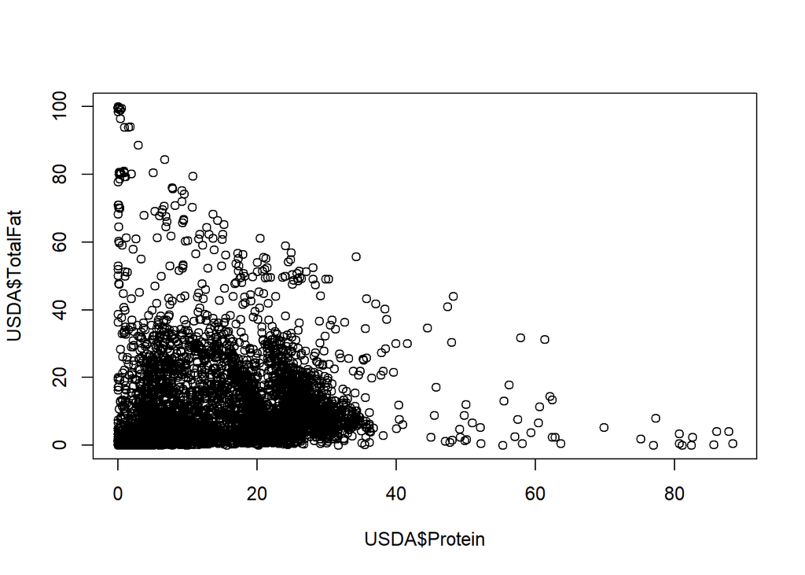

```r
  plot(USDA$Protein, USDA$TotalFat)
```

#### Add xlabel, ylabel and title

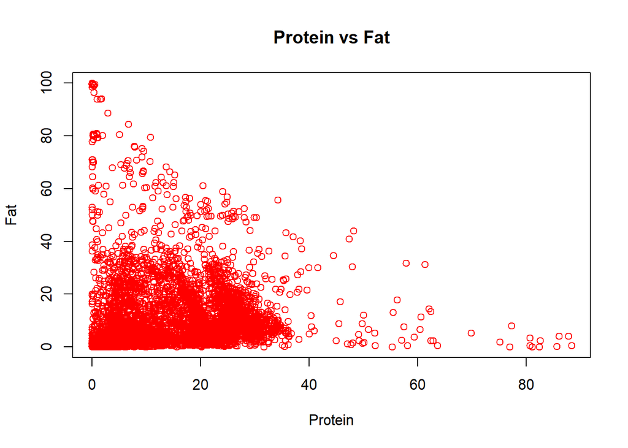

```r
  plot(USDA$Protein, USDA$TotalFat, xlab="Protein", ylab = "Fat", main = "Protein vs Fat", col = "red")
```

### Histograms

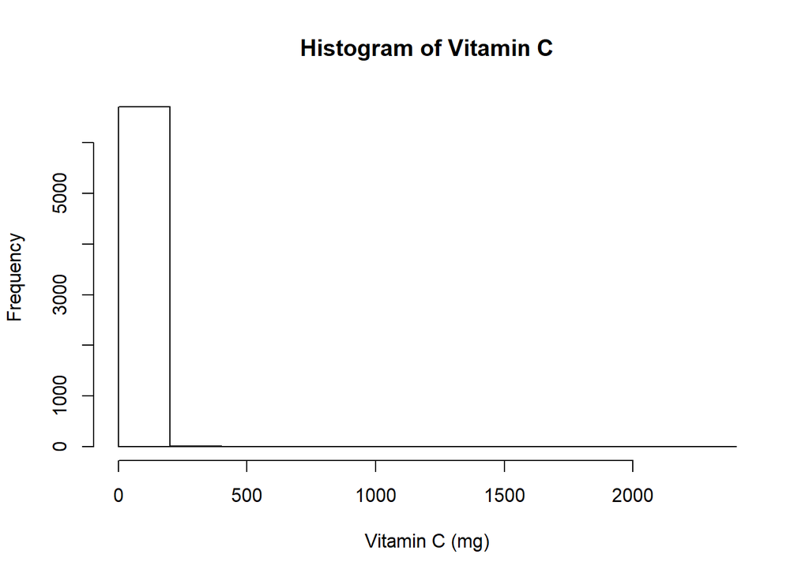

```r
  hist(USDA$VitaminC, xlab = "Vitamin C (mg)", main = "Histogram of Vitamin C")
```

#### Add limits to x-axis

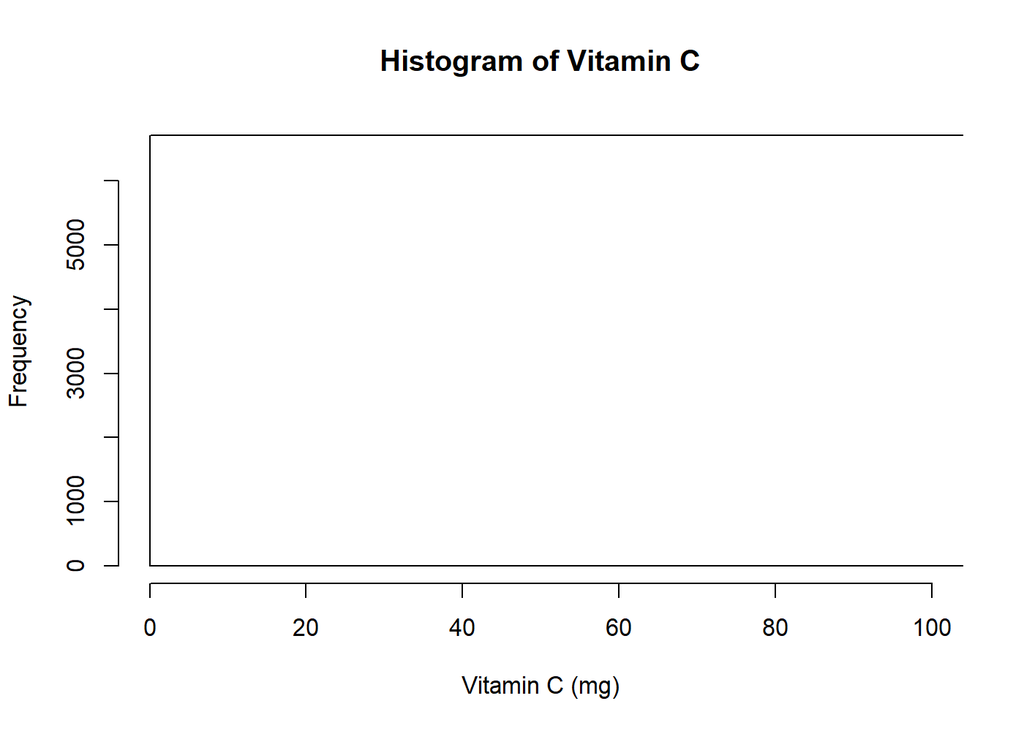

```r
  hist(USDA$VitaminC, xlab = "Vitamin C (mg)", main = "Histogram of Vitamin C", xlim = c(0,100))
```

#### Specify breaks of histogram

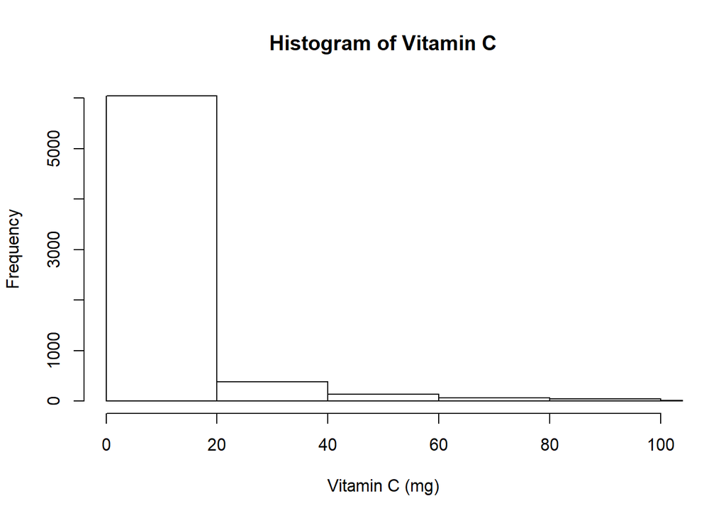

```r
  hist(USDA$VitaminC, xlab = "Vitamin C (mg)", main = "Histogram of Vitamin C", xlim = c(0,100), breaks=100)
```

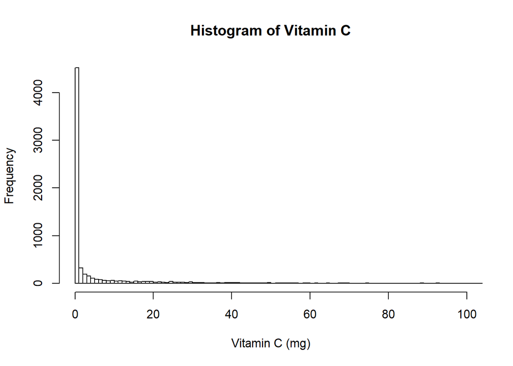

```r
  hist(USDA$VitaminC, xlab = "Vitamin C (mg)", main = "Histogram of Vitamin C", xlim = c(0,100), breaks=2000)
```

### Boxplots

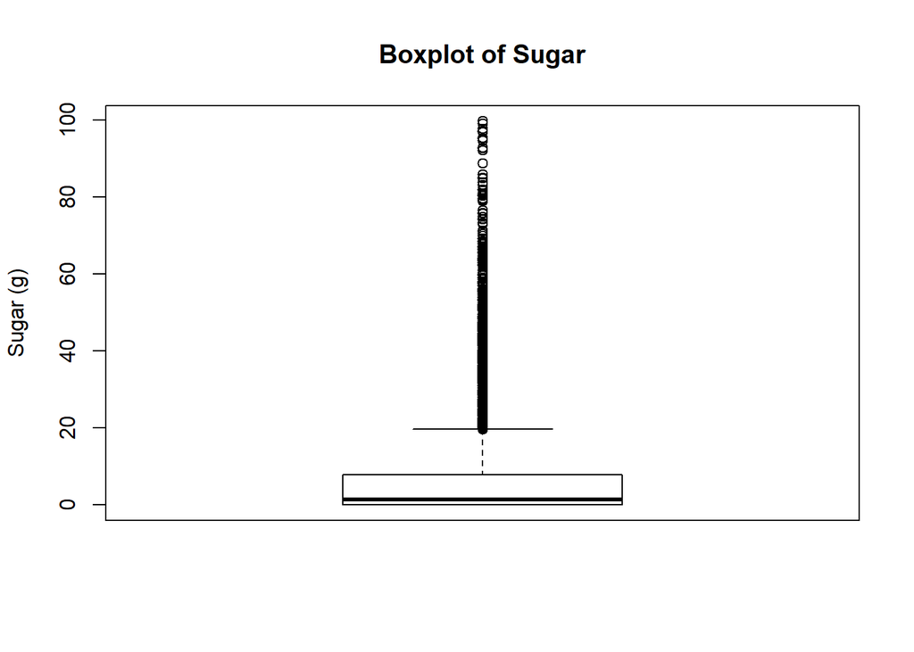

```r
  boxplot(USDA$Sugar, ylab = "Sugar (g)", main = "Boxplot of Sugar")
```

## Adding a variable

### Creating a variable that takes value 1 if the food has higher sodium than average, 0 otherwise

```r
  HighSodium = as.numeric(USDA$Sodium > mean(USDA$Sodium, na.rm=TRUE))
  str(HighSodium)
```

```
##  num [1:7058] 1 1 0 1 1 1 1 1 1 1 ...
```

### Adding the variable to the dataset

```r
  USDA$HighSodium = as.numeric(USDA$Sodium > mean(USDA$Sodium, na.rm=TRUE))
```

### Similarly for HighProtein, HigCarbs, HighFat

```r
  USDA$HighCarbs = as.numeric(USDA$Carbohydrate > mean(USDA$Carbohydrate, na.rm=TRUE))
  USDA$HighProtein = as.numeric(USDA$Protein > mean(USDA$Protein, na.rm=TRUE))
  USDA$HighFat = as.numeric(USDA$TotalFat > mean(USDA$TotalFat, na.rm=TRUE))
```

## Summary Tables

### How many foods have higher sodium level than average?

```r
  table(USDA$HighSodium)
```

```
##
##    0    1
## 4884 2090
```

### How many foods have both high sodium and high fat?

```r
  table(USDA$HighSodium, USDA$HighFat)
```

```
##
##        0    1
##   0 3529 1355
##   1 1378  712
```

### Average amount of iron sorted by high and low protein?

```r
  tapply(USDA$Iron, USDA$HighProtein, mean, na.rm=TRUE)
```

```
##        0        1
## 2.558945 3.197294
```

### Maximum level of Vitamin C in hfoods with high and low carbs?

```r
  tapply(USDA$VitaminC, USDA$HighCarbs, max, na.rm=TRUE)
```

```
##      0      1
## 1677.6 2400.0
```

### Using summary function with tapply

```r
  tapply(USDA$VitaminC, USDA$HighCarbs, summary, na.rm=TRUE)
```

```
## $`0`
##     Min.  1st Qu.   Median     Mean  3rd Qu.     Max.     NA's
##    0.000    0.000    0.000    6.364    2.800 1677.600      248
##
## $`1`
##    Min. 1st Qu.  Median    Mean 3rd Qu.    Max.    NA's
##    0.00    0.00    0.20   16.31    4.50 2400.00      83
```